# Final Assignment

Henrik Husberg, henrik.husberg@helsinki.fi

08.03 2017

# Open Data Science - Final Assignment

## Research Questions and Hypotheses

Because previous research regarding the connections between media time and attentional difficulties and school achievement has not been very clear, it is my hope that we will be able to distinguish them by a) using a method for removing measurement error (latent variables) and b) by examining separate facets of attentional difficulties and media consumption.

The current research will attempt to address some of the above mentioned issues by investigating the relationship between television time, internet use and videogame playing and ADHD-related behavior and school achievement in grades 1-9, controlling for gender and SES. Based on previous research we will test the following hypothesis:

**H1:** Media time has a small negative effect on ADHD-related behavior and school achievement.

## Data Wrangling

**Attention:** This is not a complete dataset and it may not be used outside this course. There are both variables and observations missing. Any inferences to real life are completely fictional and are only used for the purpose of this course. The dataset in its entirety belongs to the Niilo Maki Institute and results based on the complete dataset will be presented at the JURE2017 conference for those interested.

Read the data from SPSS-generated csv-file. I’ve wrangled the data quite a bit. The script can be found [here](https://github.com/hhusberg/IODS-final/blob/master/data/create_final.R).

## Data Description

The data I have is take from an ongoing study into Swedish speaking childrens’ attention and executive skills at school. The data was collected by the [Niilo Maki Institute](https://www.nmi.fi/fi) and the collection coordinated by myself and my colleague as part of our work for the [ILS-project](http://inlarningochstod.fi/). Respondents are teachers and parents of Swedish speaking children in grades 1-9 and the sample is geographically representative of Swedish speaking Finland. The data comes from three separate questionnaires: a) *Keskittymiskysely* questionnaire regarding children’s attention and executive function in the classroom (teacher reported), b) *School achievement* questionnaire regarding children’s achievement and need for support at school (teacher reported) and c) *Background* questionnaire regarding reading habits and screen time (parent reported).

Data from the questionnaires a) and b) was entered into an SPSS-matrix by myself, and coded numerically as scale or nominal variables. Data from questionnaire c) was entered into a separate SPSS-matrix by a colleague. The datafiles were merged by myself based on unique identification numbers. Some variable scales were altered in SPSS before importing the data into the Data Wrangling script for this assignment.

After wrangling around I’ve got the below datafile to work with. I’ve decided to go all continuous with this dataset. Most variables are measured on a Likert-type scale with ranges varying from 3 to 7.

```r
setwd("C:/Users/hehusb/Documents/GitHub/IODS-final")
#setwd("C:/Users/hhusberg/Documents/GitHub/IODS-final")
kesky <- read.csv2(file = "./data/final_cont.csv")
dim(kesky)
```

```
## [1] 192  88
```

```r
#str(kesky)
#str(hur_garna_lasbarn1)
```

### Attention & executive function: measured by a 55-item questionnaire

The questionnaire (ATTEX) is filled out by children’s teachers. The items are statements concerning observed problems in the classroom regarding attention and executive functions, divided into 10 subscales (presented later). All items are answered on a 3-grade Likert scale ranging from 0 (“Not a problem”) to 2 (“Often a problem”).

### School achievement: mesured by 2 questions (math/Swedish grade)

Teacher reported latest grade, or if not graded, teacher’s approximation of whcih grade the child would have received.

### Media time: Measured by 3-item questionnaire where md1 = TV time, md2 = Internet time and md3 = Video game time

Parent reported average daily time in hours child spends 1) watching television shows 2) surfing the internet and 3) playing video games. Alternatives: *not at all, less than 1 hour, 1 hour, 2 hours, 3 hours, 4 hours, 5 hours or more*.

### Reading habits: Measured by 4 questions and Reading preferences: Measured by 4 questions

Reading habits are measured on a 6-point Likert-type scale ranging from *sometimes* to *many times a day*. Reading preferences is measured on a 7-point Likert-type scale, ranging from *Very unwillingly* to *Very willingly*. For both measurements there are two questions related to homework reading (Swedish and Other) and two questions related to non-school related literature (Novels and Comics).

### Control variables: SES, here measured by mothers and fathers highest educational level and gender (Girl=1, Boy=2)

We use parents’ self-reported highest level of education as a proxy for socioeconomic status.

## Method

I will be using a combination of exploratory and confirmatory dimension reduction techniques to fit the collected data to a structural model. First, I will use Principal Component Analysis to explore the data and look for patterns. I will then interpret those patterns in relationship to existant theories regarding attention difficulties and try to fit the data to a confirmatory factor model. In the last step of my analysis I will analyze the relationships between the variables of interest using Structural Equation Modeling. This will allow me to partial out the measurement error always present in questionnaires.

## Results

First of all I want to reduce the amount of variables measuring attention. This data with 55 variables is very unyieldy. I’ll start by exploring the patterns of this data.

```r
#First I'll make a dataframe with only the ATTEX variables. The scale is all the same for these so no standardization is needed:
kesky_only <- kesky[, 2:56]
#summary(kesky_only)
dim(kesky_only)
```

```
## [1] 192  55
```

```r
#str(kesky_only)
pca_kesky <- prcomp(kesky_only)
s <- summary(pca_kesky)
# s

# rounded percetanges of variance captured by each PC
pca_pr <- round(100*s$importance[2, ], digits = 1)

# print out the percentages of variance
pca_pr
```

```
##  PC1  PC2  PC3  PC4  PC5  PC6  PC7  PC8  PC9 PC10 PC11 PC12 PC13 PC14 PC15
## 46.7  7.9  5.9  3.8  2.6  2.4  2.3  2.1  1.8  1.6  1.4  1.4  1.3  1.2  1.2
## PC16 PC17 PC18 PC19 PC20 PC21 PC22 PC23 PC24 PC25 PC26 PC27 PC28 PC29 PC30
##  1.1  1.0  1.0  0.9  0.8  0.8  0.8  0.7  0.7  0.6  0.6  0.6  0.5  0.5  0.5
## PC31 PC32 PC33 PC34 PC35 PC36 PC37 PC38 PC39 PC40 PC41 PC42 PC43 PC44 PC45
##  0.5  0.4  0.4  0.4  0.3  0.3  0.3  0.3  0.3  0.2  0.2  0.2  0.2  0.2  0.2
## PC46 PC47 PC48 PC49 PC50 PC51 PC52 PC53 PC54 PC55
##  0.1  0.1  0.1  0.1  0.1  0.1  0.1  0.1  0.0  0.0
```

```r
# create object pc_lab to be used as axis labels
pc_lab <- paste0(names(pca_pr), " (", pca_pr, "%)")
pc_lab[1:10]
```

```
##  [1] "PC1 (46.7%)" "PC2 (7.9%)"  "PC3 (5.9%)"  "PC4 (3.8%)"  "PC5 (2.6%)"
##  [6] "PC6 (2.4%)"  "PC7 (2.3%)"  "PC8 (2.1%)"  "PC9 (1.8%)"  "PC10 (1.6%)"
```

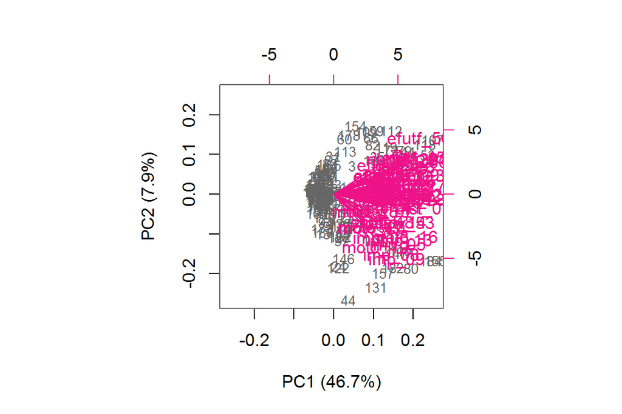

```r
# draw a biplot
biplot(pca_kesky, cex = c(0.8, 1), col = c("grey40", "deeppink2"), xlab = pc_lab[1], ylab = pc_lab[2])
```

Unfortunaltely there’s no really visible pattern here. Possibly it could be discerned that motor restlessness and some of the executive components load a bit more on PC2 (negative motor restlessness, positiv executive function) and most of the others load more on PC1. This does however not help us in reducing the dimension without losing most of the theoretical sense of the questionnaire. One of the problems with this data is that the questionnaires scale is 0-2 and the data is heavily zero-inflated- In order to increase variance and scale, I’ve formed sum variables across the ten theoretical subscales in the questionnaire, described below:

- Distractibility - 4 questions
- Impulsivity - 9 questions
- Motor restlessness - 7 questions
- Attentional direction - 5 questions
- ATtentional maintainance - 6 questions
- Attentional shifting - 4 questions
- Executive Functions, getting started - 5 questions
- Executive Functions, planning - 4 questions
- Executive Functions, executing - 8 questions
- Exectuive Functions, evaluating - 3 questions

I’ve prepared a dataset with sum scores of the items grouped under separate constructs in the questionnaire. Lets look at that.

Now as stated before, I’m interested in seeing how media usage is connected with attention at school and school achievement. I’ll start off by eyeballing my data and then doing a corrplot of the variables that interest me.

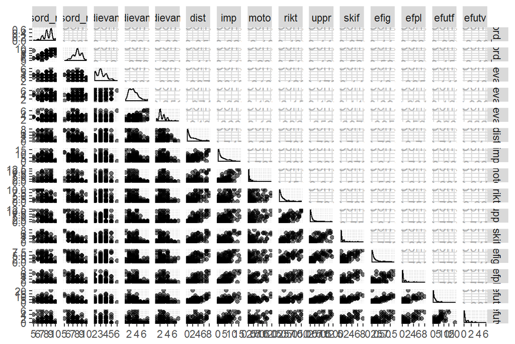

```r
setwd("C:/Users/hehusb/Documents/GitHub/IODS-final")
#setwd("C:/Users/hhusberg/Documents/GitHub/IODS-final")

kesky_sums <- read.csv2(file = "./data/final_sums_2.csv")
kesky_sums <- as.data.frame(kesky_sums)

library(GGally)
library(ggplot2)

library(corrplot)
library(dplyr)
#I'll make a subset of the most central variables of interest so I can fit it into one graph to look at the distributions:
dists <- c("vitsord_ma", "vitsord_mo", "medievanor1", "medievanor2", "medievanor3", "dist", "imp", "moto", "rikt", "uppr", "skif", "efig", "efpl", "efutf", "efutv")
subset_dists <- dplyr::select(kesky_sums, one_of(dists))

p2 <- ggpairs(subset_dists, mapping = aes(alpha = 0.3), lower = list(combo = wrap("facethist", bins = 20)))
p2
```

```r
# Need to change the gender variable to numeric to use it in the corrplot:
levels(kesky_sums$elev_kon)
```

```
## [1] "Flicka" "Pojke"
```

```r
levels(kesky_sums$elev_kon) <-c(1,2)
as.numeric(levels(kesky_sums$elev_kon))
```

```
## [1] 1 2
```

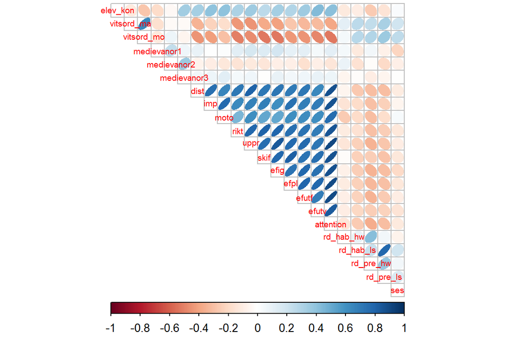

```r
kesky_sums$elev_kon <- as.numeric(kesky_sums$elev_kon)

# Correlations:
cor_matrix <- cor(kesky_sums) %>% round(digits = 2)
#cor_matrix
corrplot(cor_matrix, method="ellipse", type="upper", cl.pos="b", tl.pos="d", tl.cex=0.6)
```

Looking at the distributions we can see very clearly how heavily zero-inflated even the sum scores are. The other variables (grades and media time 1-3) show some approximations of normal distributions.

Based on the correlation plot, it does not seem like children’s media time has any strong effects on either their attention at shool, their school achievement or their reading habits. There do seem to be some effects across the variables though.

We will now look at the PCA for the sum scores of each individual area of attentional difficulties described above. Because the sum scores are made up of different amounts of items we now need to scale the data first.

```r
kesky_nona <- read.csv2(file = "./data/final_nona.csv")
kesky_nona <- as.data.frame(kesky_nona)

# Because PCA needs complete data I'll make a subset with only the ATTEX variables and filter out the NA:s:
attex_sums <- c("dist", "imp", "moto", "rikt", "uppr", "skif", "efig", "efpl", "efutf", "efutv")
nona_subset <- dplyr::select(kesky_nona, one_of(attex_sums))
kesky_nona.f <- filter(nona_subset, complete.cases(nona_subset) == TRUE)
dim(kesky_nona.f)
```

```
## [1] 501  10
```

```r
#Then scale the data and run the PCA and draw the biplot:
kesky_nona.sc <- scale(kesky_nona.f)
nona_pca <- prcomp(kesky_nona.sc)
s3 <- summary(nona_pca)
s3
```

```
## Importance of components:
##                           PC1     PC2     PC3     PC4     PC5    PC6
## Standard deviation     2.7068 0.91623 0.63764 0.53210 0.48525 0.4753
## Proportion of Variance 0.7327 0.08395 0.04066 0.02831 0.02355 0.0226
## Cumulative Proportion  0.7327 0.81663 0.85728 0.88560 0.90914 0.9317
##                            PC7     PC8     PC9    PC10
## Standard deviation     0.45017 0.42114 0.39764 0.38010
## Proportion of Variance 0.02027 0.01774 0.01581 0.01445
## Cumulative Proportion  0.95200 0.96974 0.98555 1.00000
```

```r
pca3_pr <- round(100*s3$importance[2, ], digits = 1)
pca3_pr
```

```
##  PC1  PC2  PC3  PC4  PC5  PC6  PC7  PC8  PC9 PC10
## 73.3  8.4  4.1  2.8  2.4  2.3  2.0  1.8  1.6  1.4
```

```r
pc_lab2 <- paste0(names(pca3_pr), " (", pca3_pr, "%)")
pc_lab2[1:10]
```

```
##  [1] "PC1 (73.3%)" "PC2 (8.4%)"  "PC3 (4.1%)"  "PC4 (2.8%)"  "PC5 (2.4%)"
##  [6] "PC6 (2.3%)"  "PC7 (2%)"    "PC8 (1.8%)"  "PC9 (1.6%)"  "PC10 (1.4%)"
```

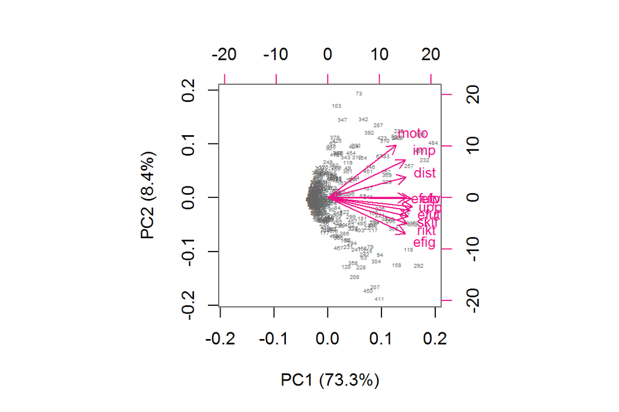

```r
biplot(nona_pca, cex = c(0.3, 0.8), col = c("grey40", "deeppink2"), xlab = pc_lab2[1], ylab = pc_lab2[2])
```

This looks much the same as the previous biplot but it’s a lot easier to read. The components seem to be clustered quite similarly. Two components would explain a bit over 80% of the variance. However, all variables seem to be quite closely related since all arrows point somewhat in the same direction. As in the PCA with all the variables above, one could separate one component having more to do with restlessness and impulsiveness (*moto* and *imp* and perhaps *dist* in the biplot) and one component having more to do with maintaining and directing attention as well as executive funtions (*uppr*, *rikt*, *efig* and *skif*). These components also seem to make theoretical sense, as motor restlessness and impulsiveness are the clearest signs of ADHD/hyperactive.

In order to be able to use this in my analyses, I’ll try to form latent variables using the sum scores. One strength of latent variables is that they can be used to reduce the dimensions of the data while factoring out the error variance. A latent variable represents some underlying factor that explains the covariance matrix shaped by the measured (or manifest) variables. A latent variable when used in confirmatory analyses should be based on theory. In this case, as stated above, it makes theoretical sense that the questionnaire could be represented by a two-factor model, where one factor explains the most visible signs of ADHD/hyperactive and the other factor explains executive difficulties such as planning and evaluating.

I’ve already lost a bit of information while forming the sum scores, but because there is not enough variance in the original variables that’s a tradeoff I’m forced to make. Next I’ll use the [lavaan package](http://lavaan.ugent.be/) in order to conduct Confirmatory Factor Analysis and Structural Equation Modeling (CFA/SEM).

```r
library(lavaan)
#Two factor model of sum variables here, hy defined by moto and imp, ef by the rest of the sum variables
kesky.model.two.sums <- ' hy =~ moto + imp
ef =~ dist + rikt + uppr + skif + efig + efpl + efutf + efutv '

# Then I'll run CFA on the above model and print the fit statistics and parameters
fit.two.sums <- cfa(kesky.model.two.sums, data = kesky_nona)
cfa.two.sums <- summary(fit.two.sums, fit.measures = TRUE, standardized =TRUE, modindices=TRUE)
```

```
## lavaan (0.5-23.1097) converged normally after  41 iterations
##
##                                                   Used       Total
##   Number of observations                           501         522
##
##   Estimator                                         ML
##   Minimum Function Test Statistic              370.939
##   Degrees of freedom                                34
##   P-value (Chi-square)                           0.000
##
## Model test baseline model:
##
##   Minimum Function Test Statistic             5202.264
##   Degrees of freedom                                45
##   P-value                                        0.000
##
## User model versus baseline model:
##
##   Comparative Fit Index (CFI)                    0.935
##   Tucker-Lewis Index (TLI)                       0.914
##
## Loglikelihood and Information Criteria:
##
##   Loglikelihood user model (H0)              -8458.625
##   Loglikelihood unrestricted model (H1)      -8273.156
##
##   Number of free parameters                         21
##   Akaike (AIC)                               16959.250
##   Bayesian (BIC)                             17047.799
##   Sample-size adjusted Bayesian (BIC)        16981.144
##
## Root Mean Square Error of Approximation:
##
##   RMSEA                                          0.141
##   90 Percent Confidence Interval          0.128  0.154
##   P-value RMSEA <= 0.05                          0.000
##
## Standardized Root Mean Square Residual:
##
##   SRMR                                           0.046
```

[output cut: 81 more lines]

```
## 64  uppr ~~  skif  10.707 -0.159  -0.159   -0.038   -0.038
## 65  uppr ~~  efig   3.763  0.125   0.125    0.023    0.023
## 66  uppr ~~  efpl   2.602 -0.070  -0.070   -0.017   -0.017
## 67  uppr ~~ efutf   4.431  0.168   0.168    0.022    0.022
## 68  uppr ~~ efutv   0.003  0.002   0.002    0.001    0.001
## 69  skif ~~  efig   8.698  0.145   0.145    0.041    0.041
## 70  skif ~~  efpl   0.126  0.012   0.012    0.004    0.004
## 71  skif ~~ efutf   3.380 -0.111  -0.111   -0.022   -0.022
## 72  skif ~~ efutv   3.064  0.049   0.049    0.025    0.025
## 73  efig ~~  efpl  14.904 -0.166  -0.166   -0.049   -0.049
## 74  efig ~~ efutf   5.988  0.195   0.195    0.031    0.031
## 75  efig ~~ efutv   7.011 -0.099  -0.099   -0.039   -0.039
## 76  efpl ~~ efutf   3.860  0.105   0.105    0.022    0.022
## 77  efpl ~~ efutv  26.434  0.128   0.128    0.067    0.067
## 78 efutf ~~ efutv   2.612 -0.074  -0.074   -0.021   -0.021
```

Lookin at the fit of the model, it does seem to work somewhat. Below I’ll print the two fit indices I will be using to judge the goodness of fit of the models:

```r
fitMeasures(fit.two.sums, "cfi")
```

```
##   cfi
## 0.935
```

```r
fitMeasures(fit.two.sums, "rmsea")
```

```
## rmsea
## 0.141
```

```r
kesky.model.two.sums.b <- ' hy =~ moto + imp + dist + efig
ef =~ dist + efig + rikt + uppr + skif + efpl + efutf + efutv
rikt ~~  skif
rikt ~~ uppr
efig ~~  rikt
efutf ~~ efutv
efpl ~~ efutv
'

fit.two.sums.b <- cfa(kesky.model.two.sums.b, data = kesky_nona, missing = 'fiml')
cfa.two.sums.b <- summary(fit.two.sums.b, fit.measures = TRUE, standardized =TRUE, modindices=TRUE)
```

```
## lavaan (0.5-23.1097) converged normally after  61 iterations
##
##   Number of observations                           522
##
##   Number of missing patterns                        12
##
##   Estimator                                         ML
##   Minimum Function Test Statistic              128.711
##   Degrees of freedom                                27
##   P-value (Chi-square)                           0.000
##
## Model test baseline model:
##
##   Minimum Function Test Statistic             5356.089
##   Degrees of freedom                                45
##   P-value                                        0.000
##
## User model versus baseline model:
##
##   Comparative Fit Index (CFI)                    0.981
##   Tucker-Lewis Index (TLI)                       0.968
##
## Loglikelihood and Information Criteria:
##
##   Loglikelihood user model (H0)              -8640.609
##   Loglikelihood unrestricted model (H1)      -8576.254
##
##   Number of free parameters                         38
##   Akaike (AIC)                               17357.218
##   Bayesian (BIC)                             17519.010
##   Sample-size adjusted Bayesian (BIC)        17398.389
##
## Root Mean Square Error of Approximation:
##
##   RMSEA                                          0.085
##   90 Percent Confidence Interval          0.071  0.100
##   P-value RMSEA <= 0.05                          0.000
##
## Standardized Root Mean Square Residual:
##
```

[output cut: 104 more lines]

```
## 76 efig ~~  skif  6.822  0.134   0.134    0.038    0.038
## 77 efig ~~  efpl  7.205 -0.105  -0.105   -0.031   -0.031
## 78 efig ~~ efutf  0.021 -0.011  -0.011   -0.002   -0.002
## 79 efig ~~ efutv  1.755 -0.047  -0.047   -0.019   -0.019
## 80 rikt ~~  efpl  0.567  0.033   0.033    0.009    0.009
## 81 rikt ~~ efutf  1.694  0.117   0.117    0.017    0.017
## 82 rikt ~~ efutv  5.898 -0.092  -0.092   -0.033   -0.033
## 83 uppr ~~  skif  6.243 -0.127  -0.127   -0.030   -0.030
## 84 uppr ~~  efpl  1.853 -0.057  -0.057   -0.014   -0.014
## 85 uppr ~~ efutf  0.978  0.082   0.082    0.011    0.011
## 86 uppr ~~ efutv  1.025  0.038   0.038    0.013    0.013
## 87 skif ~~  efpl  0.061  0.008   0.008    0.003    0.003
## 88 skif ~~ efutf  3.511 -0.114  -0.114   -0.023   -0.023
## 89 skif ~~ efutv  9.503  0.086   0.086    0.044    0.044
## 90 efpl ~~ efutf  4.593  0.118   0.118    0.025    0.025
```

By allowing these crossloadings and some correlations between manifest variables we have an acceptable model fit (CFI = .98, RMSEA = .085). Now I’ll plot this CFA-model using the *semPlot* library:

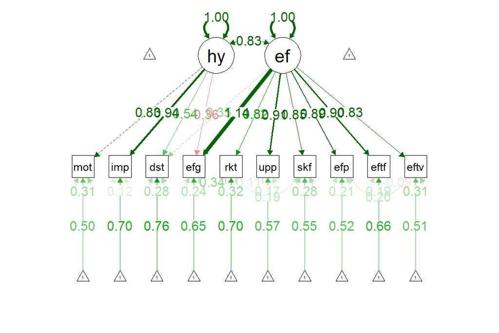

```r
library(semPlot)
semPaths(fit.two.sums.b, what="std", label.cex=1.5, edge.label.cex=1.3)
```

What we have now is an indication that the ATTEX questionnaire can be taken to measure two aspects of attentional difficulties that correspond well with the theoretical division of ADHD-like symptoms into the *hyperactive* kind and the *inattentive* kind. In the subsequent analyses we will use these latent variables to see how they are related to media consumption, reading and school achievement. In order to use the maximum amount of information but with as little *noise* or measurement error as possible, we will do this using Structural Equation Modeling. In practice that means looking at a model of regressions between latent variables. Because we cannot form latent variables for all our measurements the model will be a mixture of latent and manifest variables. In the plots, manifest variables are represented by rectangles while latent variables are represented by ovals. Indicators for latent variables are separable from other manifest variables by looking at the direction of the arrow (arrows pointing towards latent variables represent regression paths for the SEM model while arrows pointing towards a manifest variable indicates factor loadings).

Here’s my hypothesized model for the relationships:

```r
# Need to rename som variables so as to not cause too much confusion:
library(reshape)
kesky_nona <- rename(kesky_nona, c(elev_kon="gender", vitsord_mo="Swedish", vitsord_ma="Math", utb_pabygg_pappa="ed_fa", utb_pabygg_mamma="ed_mo"))

kesky.model.two.sums.c <- '

# Measurement part
hy =~ moto + imp + dist + efig
ef =~ dist + efig + rikt + uppr + skif + efpl + efutf + efutv
gpa =~ Math + Swedish
ses =~ ed_fa + ed_mo

# Structural part
#ef + hy ~ medievanor1 + medievanor2 + medievanor3
gpa ~ ef + hy + ses + gender + medievanor1 + medievanor2 + medievanor3

# Residual correlations
rikt ~~  skif
rikt ~~ uppr
efig ~~  rikt
efutf ~~ efutv
efpl ~~ efutv
'

fit.two.sums.c <- sem(kesky.model.two.sums.c, data = kesky_nona, missing='fiml')


sem.two.sums.c <- summary(fit.two.sums.c, fit.measures = TRUE, standardized =TRUE)
```

```
## lavaan (0.5-23.1097) converged normally after  96 iterations
##
##   Number of observations                           522
##
##   Number of missing patterns                        44
##
##   Estimator                                         ML
##   Minimum Function Test Statistic              380.997
##   Degrees of freedom                               116
##   P-value (Chi-square)                           0.000
##
## Model test baseline model:
##
##   Minimum Function Test Statistic             6020.038
##   Degrees of freedom                               147
##   P-value                                        0.000
##
## User model versus baseline model:
##
##   Comparative Fit Index (CFI)                    0.955
##   Tucker-Lewis Index (TLI)                       0.943
##
## Loglikelihood and Information Criteria:
##
##   Loglikelihood user model (H0)             -12864.828
##   Loglikelihood unrestricted model (H1)     -12674.330
##
##   Number of free parameters                         59
##   Akaike (AIC)                               25847.657
##   Bayesian (BIC)                             26098.859
##   Sample-size adjusted Bayesian (BIC)        25911.580
##
## Root Mean Square Error of Approximation:
##
##   RMSEA                                          0.066
##   90 Percent Confidence Interval          0.059  0.074
##   P-value RMSEA <= 0.05                          0.000
##
## Standardized Root Mean Square Residual:
##
```

[output cut: 84 more lines]

```
##    .efig              1.032    0.093   11.140    0.000    1.032    0.230
##    .rikt              1.784    0.125   14.230    0.000    1.784    0.317
##    .uppr              1.086    0.085   12.793    0.000    1.086    0.169
##    .skif              0.767    0.053   14.360    0.000    0.767    0.282
##    .efpl              0.538    0.040   13.382    0.000    0.538    0.213
##    .efutf             1.677    0.129   13.019    0.000    1.677    0.192
##    .efutv             0.442    0.031   14.049    0.000    0.442    0.317
##    .Math              0.627    0.068    9.199    0.000    0.627    0.539
##    .Swedish           0.254    0.068    3.721    0.000    0.254    0.269
##    .ed_fa             1.122    0.237    4.743    0.000    1.122    0.560
##    .ed_mo             0.888    0.172    5.152    0.000    0.888    0.585
##     hy                3.838    0.336   11.411    0.000    1.000    1.000
##     ef                0.407    0.122    3.334    0.001    1.000    1.000
##    .gpa               0.307    0.050    6.158    0.000    0.571    0.571
##     ses               0.881    0.254    3.470    0.001    1.000    1.000
```

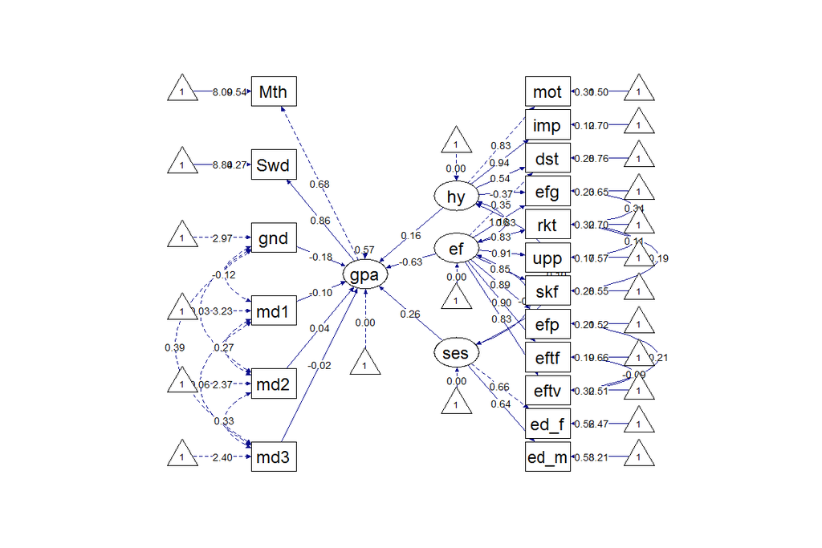

```r
semPaths(fit.two.sums.c,style="lisrel",
        whatLabels = "std", edge.label.cex = .6, node.label.cex = .6,
        label.prop=0.9, edge.label.color = "black", rotation = 4,
        equalizeManifests = FALSE, optimizeLatRes = TRUE, node.width = 1.5,
        edge.width = 0.5, shapeMan = "rectangle", shapeLat = "ellipse",
        shapeInt = "triangle", sizeMan = 4, sizeInt = 2, sizeLat = 4,
        curve=2, unCol = "#070b8c")
```

This model fits the data pretty well (CFI = .955, RMSEA = .066). In it media time is included as three separate manifest variables (md1-md3). From the output under *Regressions* we can see that the *ef* factor, what I’ve here called Executive Function difficulties, does indeed have a statistically significant negative relationship with students’ *gpa* ($\beta = -.63$). Interistingly, the *hy* factor, hyperactivity, does not have a significant effect on *gpa*. The effect of *gender* is significant ($\beta = -.18$), a negative correlation here indicating that girls (coded as 1) have better *gpa* than boys (coded as 2). Finally, higher *ses* corresponds with higher *gpa* ($\beta = .26$).

None of the three manifest variables for media time had any significant effect on *gpa* when included in a model controlling for gender and socioeconomic status.

## Discussion

*Here I will remind readers that this is still a preliminary analysis based in incomplete data and that the full analysis will be presented at JURE2017 in Tampere.*

First of all, the CFA model of the ATTEX-questionnaire seems to validate previous findings (using a different sample and different techniques for analysis) of the questionnaires ability to discriminate ADHD symptoms of the hyperactive kind from the inattentive kind. This in and of itself is valuable information.

Also, based on the above results it might be the case that the negative effects of media time are less than previously feared, if significant at all. These results support previous research showing that it would most probably be more fruitful to focus on other variables affecting children’s school achievement.

Other important results presented in this study is the fact that while inattentive symptoms seem to affect students’ grade point average, hyperactive symptoms do not. This is potentially important information for practitioners, since the hyperactive symptoms are the ones to usually receive more attention. This us due to the fact that they are more visible and more disruptive in the classroom. The reason why they do not negatively affect GPA while inattentive symptoms do could be one of two: a) the hyperactive children get more and faster help with their difficulties because they are more easily noticed or b) they actually struggle more at school because of differences between the two types of difficulties. In order to see which is the case we will need to collect data from a) tests of ability and/or b) amount of support received.